# GameInformer: Relational Database Design

## Introduction

[figure not shown]

## Entity Relationship Diagram

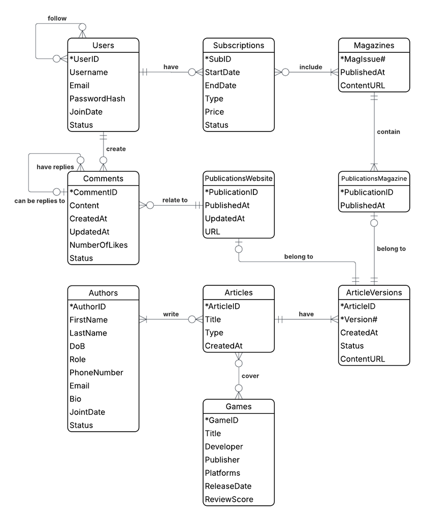

## Articles

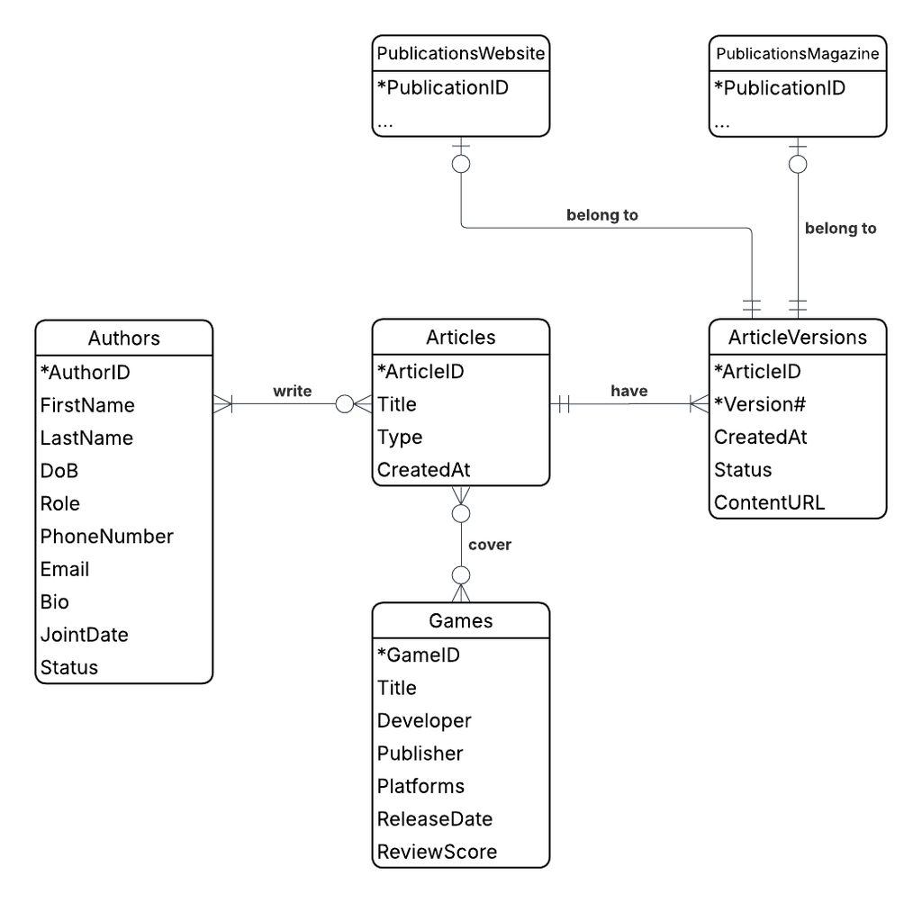

## Publications

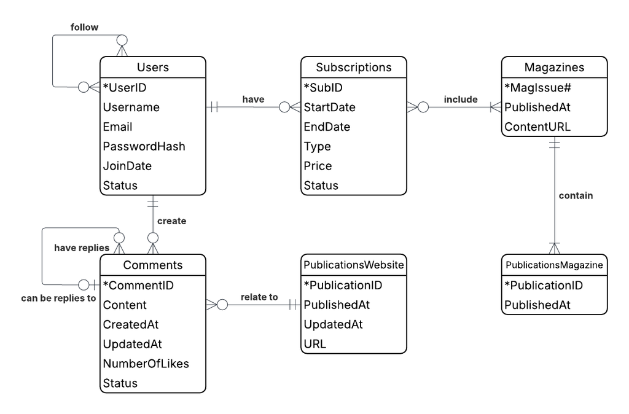

## Entity Relationship Diagram

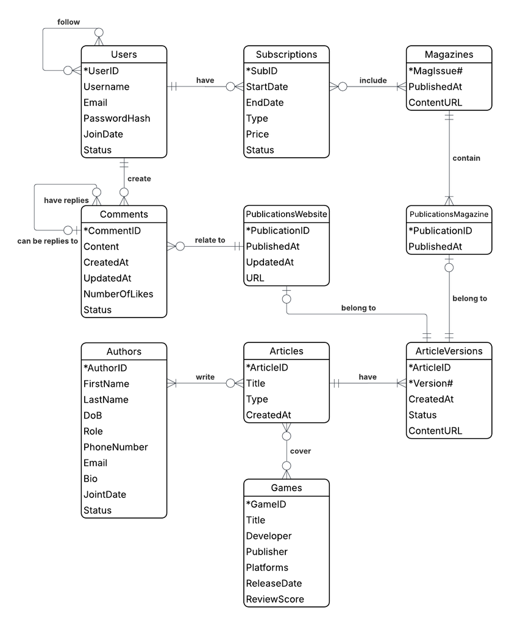

## Binary, Many to Many

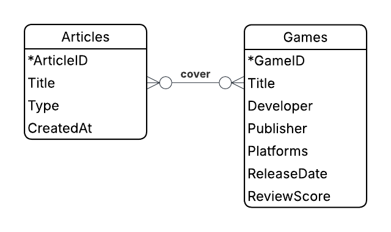

[figure not shown]

- **Articles** (ArticleID, Title, Type, CreatedAt)
- **Games** (GameID, Title, Developer, Publisher, Platforms, ReleaseDate, ReviewScore)
- **Articles_Games** (ArticleID (fk), GameID (fk))

## One to Many (Binary and Unary)

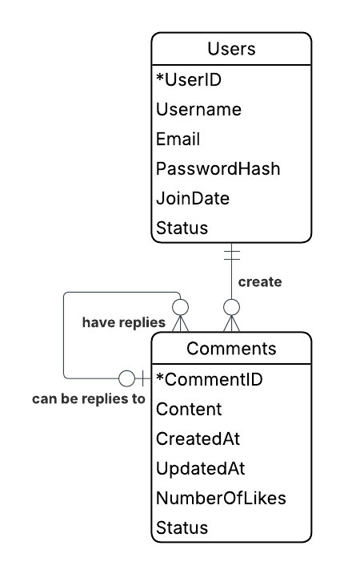

- **Users** (UserID, Username, Email, PasswordHash, JoinDate, Status)
- **Comments** (CommentID, Content, CreatedAt, UpdatedAt, NumberOfLikes, Status, UserID (fk), ParentCommentID (fk))

## Relational Model

- **Articles** (ArticleID, Title, Type, CreatedAt).
- **ArticleVersions** (ArticleID (fk), Version#, CreatedAt, Status, ContentURL).
- **Authors** (AuthorID, FirstName, LastName, DoB, Role, PhoneNumber, Email, Bio, JointDate, Status).
- **Authors_Articles** (ArticleID (fk), AuthorID (fk)).
- **Games** (GameID, Title, Developer, Publisher, Platforms, ReleaseDate, ReviewScore).
- **Articles_Games** (ArticleID (fk), GameID (fk)).
- **PublicationsWebsite** (PublicationID, PublishedAt, UpdatedAt, URL, ArticleID (fk), Version# (fk)).
- **PublicationsMagazine** (PublicationID, PublishedAt, ArticleID (fk), Version# (fk), MagIssue# (fk)).
- **Magazines** (MagIssue#, PublishedAt, ContentURL).
- **Subscriptions** (SubID, StartDate, EndDate, Type, Price, Status, UserID (fk)).
- **Subscriptions_Magazines** (SubID (fk), MagIssue# (fk)).
- **Users** (UserID, Username, Email, PasswordHash, JoinDate, Status).
- **Users_Users** (UserID (fk), FollowerID (fk)).
- **Comments** (CommentID, Content, CreatedAt, UpdatedAt, NumberOfLikes, Status, UserID (fk), ParentCommentID (fk), PublicationID (fk)).

## Publications: normalization process

[figure not shown]

- **PublicationsWebsite** (PublicationID, PublishedAt, UpdatedAt, URL, ArticleID (fk), Version# (fk))
  - FD1: PublicationID –> PublishedAt, UpdatedAt, URL, ArticleID, Version#
  - FD2: ArticleID –> PublicationID, PublishedAt, UpdatedAt, URL, Version#

⇓

- **PublicationsWebsite** (ArticleID (fk), PublishedAt, UpdatedAt, URL, Version# (fk))
  - FD1: ArticleID –> PublishedAt, UpdatedAt, URL, Version#

## Publications: normalization process

[figure not shown]

- **PublicationsMagazine** (PublicationID, PublishedAt, ArticleID (fk), Version# (fk), MagIssue# (fk))
  - FD1: PublicationID –> PublishedAt, ArticleID, Version#, MagIssue#
  - FD2: ArticleID –> PublicationID, PublishedAt, Version#, MagIssue#
  - FD3: MagIssue# –> PublishedAt

⇓

- **PublicationsMagazine** (ArticleID (fk), PublishedAt, Version# (fk), MagIssue# (fk))
  - FD1: ArticleID –> PublishedAt, Version#, MagIssue#
  - FD3: MagIssue# –> PublishedAt

⇓

- **PublicationsMagazine** (ArticleID (fk), Version# (fk), MagIssue# (fk))
  - FD1: ArticleID –> Version#, MagIssue#
- **Magazines** (MagIssue#, PublishedAt, ContentURL)

## Subscriptions: normalization process

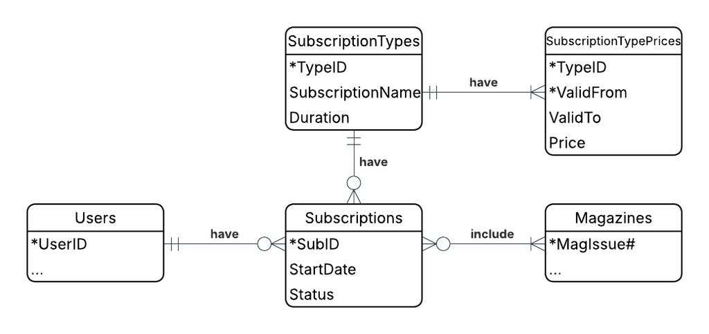

- **Subscriptions** (SubID, StartDate, EndDate, Type, Price, Status, UserID (fk))
  - FD1: SubID –> StartDate, EndDate, Type, Price, Status, UserID
  - FD2: Type, StartDate, EndDate –> Price

⇓

- **Subscriptions** (SubID, StartDate, Status, UserID (fk), TypeID (fk)).
  - FD1: SubID –> StartDate, Status, UserID, TypeID
- **SubscriptionTypes** (TypeID, SubscriptionName, Duration).
  - FD1: TypeID –> SubscriptionName, Duration
- **SubscriptionTypePrices** (TypeID (fk), ValidFrom, ValidTo, Price)
  - FD1: TypeID, ValidFrom –> ValidTo, Price